# Numbers

Session 27: Building a Development Index, Step by Step

Ayush Patel

National Law School of India University, Bengaluru

08 Sep, 2026

# A different kind of combining

## Last time: counting deprivations

Last session we built our own poverty index.

We counted how many things each student lacked, and by how much.

## This time: no counting

Today nobody is simply deprived or not deprived.

We have continuous measurements, in completely different units.

## The real world problem

Countries are compared on life expectancy, years of schooling, and income.

Years, years, and rupees or dollars. Very different units.

## The Human Development Index

The Human Development Index, or HDI, solves exactly this problem (**hdr2020tech?**).

It turns three very different measurements into one score between 0 and 1.

## Same two building blocks, one difference

We still need to pick our dimensions and pick a way to combine them.

But there is no poor or non-poor split this time. Everyone gets a score.

# Meet the class, again

## The same six students

Aditi, Zara, Rohan, Kabir, Meera, and Dev.

This time we ask a different question about them.

## Not “who lacks what”

Instead we ask: how well is each student doing, on a continuous scale?

## Three dimensions, HDI style

HDI uses three dimensions: a long and healthy life, knowledge, and a decent standard of living (**hdr2020tech?**).

We will use a classroom version of each.

## Our three dimensions

**A healthy routine**: how many school days a student actually attends.

**Knowledge**: a vocabulary score, and books read for pleasure.

**Standard of living**: weekly pocket money.

# Step 1: The raw data

## Four things we measure

Days present out of 200 school days.

A vocabulary test score out of 50.

Books read this year.

Weekly pocket money, in rupees.

## Our achievement matrix

| Student | Days present (out of 200) | Vocabulary score (/50) | Books read this year | Pocket money (₹/week) |
| --- | --- | --- | --- | --- |
| Aditi | 190 | 45 | 30 | 300 |
| Zara | 175 | 35 | 15 | 150 |
| Rohan | 150 | 25 | 8 | 80 |
| Kabir | 165 | 20 | 5 | 200 |
| Meera | 140 | 15 | 10 | 60 |
| Dev | 130 | 10 | 3 | 40 |

Four raw numbers per student, in four different units.

# Step 2: The normalization problem

## We cannot just add these up

190 days plus 45 points plus ₹300 means nothing on its own.

Days, test points, and rupees are not the same kind of thing.

## HDI’s solution

Turn every raw number into an index between 0 and 1 first.

Only then combine the indices.

## Fixed reference points

To do this, HDI sets a minimum and a maximum for each indicator (**hdr2020tech?**).

These are called goalposts.

## Goalposts are normative, again

The minimum is a realistic floor. The maximum is an aspirational target.

Just like our deprivation cutoffs last session, someone had to choose these.

## The normalization formula

$$\text{Index} = \frac{\text{actual value} - \text{minimum}}{\text{maximum} - \text{minimum}}$$

This rescales any raw number onto a common 0 to 1 scale.

# Step 3: Setting our goalposts

## Choosing sensible bounds

Days present: floor of 120 days, aspirational target of 195 days.

Vocabulary score: floor of 0, maximum possible score of 50.

Books read: floor of 0, aspirational target of 40 books a year.

Pocket money: floor of ₹10 a week, aspirational target of ₹500 a week.

## Same matrix, goalposts added

| Student | Days present (out of 200) | Vocabulary score (/50) | Books read this year | Pocket money (₹/week) |
| --- | --- | --- | --- | --- |
| Aditi | 190 | 45 | 30 | 300 |
| Zara | 175 | 35 | 15 | 150 |
| Rohan | 150 | 25 | 8 | 80 |
| Kabir | 165 | 20 | 5 | 200 |
| Meera | 140 | 15 | 10 | 60 |
| Dev | 130 | 10 | 3 | 40 |
| Goalpost (min–max) | 120–195 | 0–50 | 0–40 | 10–500 |

Every column now has its own floor and ceiling.

# Step 4: The health dimension

## The simplest case

Days present only needs one indicator.

We apply the normalization formula directly.

## Aditi’s health index, worked out

$$\text{Health}_{\text{Aditi}} = \frac{190 - 120}{195 - 120} = \frac{70}{75} \approx 0.933$$

Aditi attends school almost as often as our aspirational target.

## Dev’s health index, worked out

$$\text{Health}_{\text{Dev}} = \frac{130 - 120}{195 - 120} = \frac{10}{75} \approx 0.133$$

Dev is much closer to our floor of 120 days.

## Health index for everyone

| Student | Health index | Vocabulary score (/50) | Books read this year | Pocket money (₹/week) |
| --- | --- | --- | --- | --- |
| Aditi | 0.933 | 45 | 30 | 300 |
| Zara | 0.733 | 35 | 15 | 150 |
| Rohan | 0.400 | 25 | 8 | 80 |
| Kabir | 0.600 | 20 | 5 | 200 |
| Meera | 0.267 | 15 | 10 | 60 |
| Dev | 0.133 | 10 | 3 | 40 |

One raw column has become one clean index, between 0 and 1.

# Step 5: The knowledge dimension

## Two indicators this time

Knowledge has both a vocabulary score and a books-read count.

Each needs its own index first.

## Normalize the vocabulary score

$$\text{Vocabulary index} = \frac{\text{score} - 0}{50 - 0}$$

## Normalize books read

$$\text{Books index} = \frac{\text{books} - 0}{40 - 0}$$

## Both sub-indices for everyone

| Student | Health index | Vocabulary index | Books index | Pocket money (₹/week) |
| --- | --- | --- | --- | --- |
| Aditi | 0.933 | 0.900 | 0.750 | 300 |
| Zara | 0.733 | 0.700 | 0.375 | 150 |
| Rohan | 0.400 | 0.500 | 0.200 | 80 |
| Kabir | 0.600 | 0.400 | 0.125 | 200 |
| Meera | 0.267 | 0.300 | 0.250 | 60 |
| Dev | 0.133 | 0.200 | 0.075 | 40 |

## Combining the two sub-indices

HDI combines the two schooling-type indicators with a plain arithmetic mean (**hdr2020tech?**).

$$\text{Knowledge} = \frac{\text{Vocabulary index} + \text{Books index}}{2}$$

## Why an arithmetic mean here

An arithmetic mean lets one sub-indicator make up for the other (**hdr2020tech?**).

A student strong in vocabulary but light on reading can still land in the middle.

## Knowledge index for everyone

| Student | Health index | Knowledge index | Pocket money (₹/week) |
| --- | --- | --- | --- |
| Aditi | 0.933 | 0.825 | 300 |
| Zara | 0.733 | 0.537 | 150 |
| Rohan | 0.400 | 0.350 | 80 |
| Kabir | 0.600 | 0.263 | 200 |
| Meera | 0.267 | 0.275 | 60 |
| Dev | 0.133 | 0.138 | 40 |

# Step 6: The standard of living dimension

## Money behaves differently

Pocket money could be normalized the same simple way.

But HDI treats income differently, on purpose (**hdr2020tech?**).

## Diminishing returns

An extra ₹50 means a lot to a student with ₹40 a week.

That same ₹50 means far less to a student who already has ₹300 a week.

## The natural logarithm

To capture this, HDI takes the natural log of income before normalizing (**hdr2020tech?**).

$$\text{Income index} = \frac{\ln(\text{actual}) - \ln(\text{minimum})}{\ln(\text{maximum}) - \ln(\text{minimum})}$$

## Kabir’s income index, worked out

$$\text{Income}_{\text{Kabir}} = \frac{\ln(200) - \ln(10)}{\ln(500) - \ln(10)} \approx 0.766$$

Kabir’s pocket money looks modest in rupees, but scores fairly high after logging.

## Income index for everyone

| Student | Health index | Knowledge index | Income index |
| --- | --- | --- | --- |
| Aditi | 0.933 | 0.825 | 0.869 |
| Zara | 0.733 | 0.537 | 0.692 |
| Rohan | 0.400 | 0.350 | 0.532 |
| Kabir | 0.600 | 0.263 | 0.766 |
| Meera | 0.267 | 0.275 | 0.458 |
| Dev | 0.133 | 0.138 | 0.354 |

We now have three clean dimension indices for every student.

# Step 7: Putting the three together

## The final aggregation step

HDI combines the three dimension indices with a geometric mean (**hdr2020tech?**).

$$\text{HDI} = \left(\text{Health} \times \text{Knowledge} \times \text{Income}\right)^{1/3}$$

## Aditi’s HDI, worked out

$$\text{HDI}_{\text{Aditi}} = \left(0.933 \times 0.825 \times 0.869\right)^{1/3} \approx 0.875$$

## HDI for the whole class

| Student | Health index | Knowledge index | Income index | HDI |
| --- | --- | --- | --- | --- |
| Aditi | 0.933 | 0.825 | 0.869 | 0.875 |
| Zara | 0.733 | 0.537 | 0.692 | 0.649 |
| Rohan | 0.400 | 0.350 | 0.532 | 0.421 |
| Kabir | 0.600 | 0.263 | 0.766 | 0.494 |
| Meera | 0.267 | 0.275 | 0.458 | 0.323 |
| Dev | 0.133 | 0.138 | 0.354 | 0.187 |

## Ranking our class

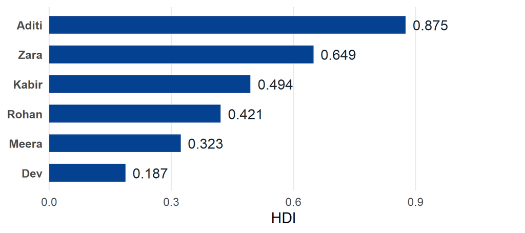

Figure 1

# Step 8: Why a geometric mean?

## A different way to average

We could have just averaged the three indices instead.

$$\text{Arithmetic mean} = \frac{\text{Health} + \text{Knowledge} + \text{Income}}{3}$$

## Look closely at Kabir

Kabir’s three indices are uneven: 0.600, 0.263, and 0.766.

Strong in health and income, weak in knowledge.

## Two ways to average Kabir’s scores

**Arithmetic mean**  
$(0.600+0.263+0.766)/3$  
$\approx 0.543$

**Geometric mean**  
$(0.600 \times 0.263 \times 0.766)^{1/3}$  
$\approx 0.494$

## What this shows

The geometric mean gives Kabir a lower score than the arithmetic mean.

A weak dimension pulls the geometric mean down more than a simple average.

Being strong in two dimensions cannot fully cover for being weak in a third.

# Step 9: Scoring the whole class

## A natural next question

Individual scores are useful. But what is our class’s overall HDI?

## The tempting shortcut

We could just average everyone’s HDI scores together.

$$\text{Naive class HDI} = \frac{0.875+0.649+0.421+0.494+0.323+0.187}{6} \approx 0.491$$

## That shortcut is not how HDI is aggregated

Official HDI group figures are not an average of individual HDI values (**hdr2020tech?**).

Instead, the raw indicators are averaged first, and the HDI formula is applied once, to those averages (**hdr2020tech?**).

## Averaging the raw indicators first

| Indicator | Days present | Vocabulary score | Books read | Pocket money |
| --- | --- | --- | --- | --- |
| Class average | 158.3 | 25.0 | 11.8 | ₹138.3 |

## Recomputing HDI from these averages

$$\text{Health} = 0.511, \quad \text{Knowledge} = 0.398, \quad \text{Income} = 0.672$$

$$\text{Correct class HDI} = (0.511 \times 0.398 \times 0.672)^{1/3} \approx 0.515$$

## Two answers, side by side

**Naive shortcut**  
average of individual HDIs  
$\approx 0.491$

**Correct method**  
HDI of the class averages  
$\approx 0.515$

The two methods do not agree.

## Why they disagree

HDI mixes a logarithm and a geometric mean.

Neither of those treats an average of outputs the same as the output of an average.

## The takeaway for policy

Never average already-computed HDI values across a population.

Average the underlying indicators first, then apply the HDI formula once.

## A contrast worth noticing

Our gMPI last session could be split by section using a simple population-share sum.

HDI cannot be split that way. It must be rebuilt from the raw indicators each time.

# From our classroom to the real HDI

## Checking our formula on a real country

The technical note itself works through an example: Sudan (**hdr2020tech?**).

We can run Sudan’s numbers through our own formula and see if we agree.

## Sudan’s raw indicators

Life expectancy at birth: 65.3 years.

Expected years of schooling: 7.9 years.

Mean years of schooling: 3.8 years.

Gross national income per capita: $3,829 (**hdr2020tech?**).

## The real HDI goalposts

Life expectancy: floor of 20 years, target of 85 years.

Expected years of schooling: floor of 0, target of 18 years.

Mean years of schooling: floor of 0, target of 15 years.

Income per capita: floor of $100, target of $75,000 (**hdr2020tech?**).

## Computing Sudan’s dimension indices

$$\text{Health} \approx 0.697, \qquad \text{Education} \approx 0.346, \qquad \text{Income} \approx 0.551$$

Education is the average of the expected and mean schooling indices.

## Sudan’s HDI, our way

$$\text{HDI}_{\text{Sudan}} = (0.697 \times 0.346 \times 0.551)^{1/3} \approx 0.510$$

## Small gaps are just rounding

That gap comes from rounding the published inputs, not from a different formula.

## Where Sudan sits

Human development categories: very high from 0.800, high from 0.700, medium from 0.550, and low below that (**hdr2020tech?**).

At 0.510, Sudan falls into the low human development category.

# Recap

## What we built today

We turned four raw numbers into three dimension indices using fixed goalposts.

We used an arithmetic mean within knowledge, and a log transform for income.

We combined all three with a geometric mean to get HDI.

## What we learned about aggregating groups

A population’s HDI is not the average of its members’ HDI values.

It comes from re-averaging the raw indicators, then applying the formula once.